# Model overview

Lyndon Estes

06 January 2015

The model (`trademod`) has 5 major modules:

1. **Master** module, where flexible parameters are set and runs controlled. The master module calls the following modules/functions in order:
2. **Targets**, which calculates the amount of each crop (in tonnes) that needs to be produced.
- This may also readjust the cropland fractional share as a function of the relative demand increase for each crop.
3. **Constraints**, which applies the various land use constraints on top of the main constraint, which is the land’s productivity for a given crop. The formulation of the land use constraints follows Koh and Ghazoul (2010):

   $\begin{aligned} C_{ij} = \beta_0Y_{ij} \beta_1c1_{ij} \beta_2c2_{ij} \beta_3c3_{ij} \end{aligned}$

   Where $C_{ij}$ are the total constraints on production for crop i in pixel j, $Y$ is crop i’s yield potential, $c1-3$ are constraints for carbon, biodiversity, and transport costs, respectively, and $\beta_0$ is a positive coefficent (from 0 to some arbitary multiple, but the maximum should be line with realistic potential yield gains) that modifies the yield potential of crop i in some way. Here we will use grids representing climate change impacts and irrigation-based increases, respectively, to provide these values, so $\beta_0$ will be the product of two coefficients. $\beta_{1-3}$ range between 0-1, where 0 means the constraint is not applied, and 1 that it is fully applied, with values in between representing partial weights. Theoretically, this value could be greater than 1, which would simply place a greater weight on that constraint. This means that:

   $\begin{aligned} P_{ij} = C_{ij} \end{aligned}$

   That is, the probability $P$ that pixel j is converted to crop i is equivalent to the product of the constraints $C$. Let’s demonstrate whether this is the correct way of going about things or not, that is, multiplicatively as opposed to additively. First, we’ll set up a dummy matrix representing three constraints (c1-3) on three pixels (p1-3).

   ```r
   options(width = 90)
   set.seed(3)
   pmat <- sapply(1:3, function(x) sample(1:100, 3) / 100)
   pmat
   ```

   ```
   ##      [,1] [,2] [,3]
   ## [1,] 0.17 0.33 0.13
   ## [2,] 0.80 0.60 0.30
   ## [3,] 0.38 0.99 0.57
   ```

   Here’s are the rankings when we assume that all pixels have a $\beta$ of 1 and we multiply, and also when we add constraints and divide by 3. Here we’ll just see whether each pixel’s probability rank is the same under the different schemes.

   ```r
   unname(rank(apply(pmat, 1, prod)) == rank(rowSums(pmat) / 3))
   ```

   ```
   ## [1] TRUE TRUE TRUE
   ```

   So they produce the same ranks. But let’s try this a bit more robustly, with more pixels and more random permutations of probabilities.

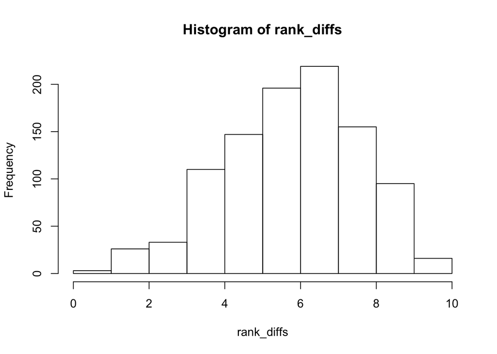

   ```r
   set.seed(3)
   rank_diffs <- sapply(1:1000, function(x) {
     pmat <- t(sapply(1:10, function(x) sample(1:100, 10) / 100))
     d <- rank(apply(pmat, 1, prod), ties.method = "first") - rank(rowSums(pmat) / 10, ties.method = "first")
     d[d != 0] <- 1
     sum(d)
   })
   hist(rank_diffs)
   ```

   So these are not at all the same. In any case, let’s go with multiplying, since we are creating a probability, and probabilities should be multiplied.
4. **Convert**, which converts the area of cropland necessary to hit $T_i$, which is the target production in tonnes for crop i:

   $\begin{aligned} A_i = \sum_{j=max(P_i)}^{t} fa_i \end{aligned}$

   Where $A_i$ is the total area converted, as determined by summing the area of each pixel $a$ converted for crop i, multiplied by the fraction $f$ available in that pixel for converting to that crop (predetermined and possibly modified by the **Targets** module). Conversion begins in the pixel where $P_i$ is greatest, and ends in pixel $t$, which is the last pixel where:

   $\begin{aligned} T_i \leq \sum_{j=max(P_i)}^{t} fa_iY_i \end{aligned}$
5. **Impacts**, which, in addition to the total area converted will assess some impacts for each scenario, which must still be developed, such as the total $CO_2$ emissions, some sort of biodiversity impact metric, some water use metric, etc. Ideas for biodiversity
- Species loss metric (e.g. matrix weighted species area curve; (Koh and Ghazoul 2010)$)
- Fragmentation metric
- Mean richness metric per converted pixel

References

Koh, Lian Pin, and Jaboury Ghazoul. 2010. “Spatially Explicit Scenario Analysis for Reconciling Agricultural Expansion, Forest Protection, and Carbon Conservation in Indonesia.” *Proceedings of the National Academy of Sciences* 107 (24): 11140–44. doi:10.1073/pnas.1000530107. http://www.pnas.org/content/107/24/11140.